# Bayesian MUNE - A Novel Approach (Progress)

Siebe Everaerts

2026-09-24

# MUNE

## Introduction

Some medical disorders are associated with a progressive loss of motor units. For example, in amyotrophic lateral sclerosis (ALS), motor unit numbers appear to decline according to an exponential decay pattern (Baumann et al., 2012). Therefore, it is important to estimate the number of motor units reliably and effectively. Several statistical methods have been developed for this purpose. One widely used approach is the method proposed by Bostock (2016), in which an error function is optimized through a refitting procedure that optimizes for some unit specific and general parameters. Another approach is the Bayesian method proposed by Ridall et al. (2006), in which a probabilistic model is constructed based on three underlying assumptions. The model is then fitted separately for a range of plausible values of $U$, to estimate the posterior probability of $P(N \mid Y)$. Here we propose a new model of estimating $U$ (the total number of motor units). We will build from the ground up and add complexity as we go along.

## Model

### Stochastic process

It is known that a motor unit fires when a threshold level of voltage change, resulting from ion movements across the cell membrane, is reached. These voltage changes within the cell can be induced by electrical stimulation (mV) and so can the threshold. Since we are working with CMAP recordings we only have access to electrical stimulation to the surface (mV), which is why our thresholds will be located in this space. However, this firing threshold is not fixed and fluctuates over time due to variations in ion channel activity. Researchers have found that this within-unit variability in firing threshold can be modelled well by a Gaussian distribution (Hales et al., 2004). Thus, for $N$ observations, with stimulus $S_i$, where $i \in \{1,2,\ldots,N\}$, the threshold of motor unit $u$, where $u \in \{1,2,\ldots,U\}$, can be modelled as normally distributed:
$$\tau_{i,u} \sim N(\mu_{\tau},\sigma_{\tau})$$
This variation results in a stochastic rather than deterministic firing pattern for individual motor units, as their firing thresholds fluctuate over time. Once the instantaneous threshold is crossed, the motor unit fires. Estimating a separate threshold for every combination of stimulus and motor unit would therefore introduce a very large number of parameters into the model. Fortunately, previous research has shown that motor units respond to varying stimulus intensities according to a unit-specific firing curve that can be characterized by a sigmoidal activation function (Brown & Milner-Brown, 1976; Slawnych et al., 1996). By marginalizing over the distribution of the within-unit firing threshold, it is possible to account for this stochasticity without estimating a separate threshold for every stimulus–unit combination. This results in a probabilistic response curve describing the probability that motor unit $u$ fires in response to stimulus $i$. Because the within-unit thresholds are normally distributed, the probability that motor unit $u$ fires in response to stimulus $i$ is:
$$P(\text{fire}_{i,u})=\int_{-\infty}^{S_i}
\frac{1}{\sigma_{\tau}\sqrt{2\pi}}\exp\left[-\frac{(\tau-\mu_{\tau})^2}{2\sigma_{\tau}^2}\right]d\tau$$
$$P(\text{fire}_{i,u})=\Phi\left(\frac{S_s-\mu_{\tau}}{\sigma_{\tau}}\right)$$
For the simple case of $U=3$, the probabilistic response curves can be plotted as a function of stimulus intensity, assuming a fixed, shared threshold mean and variance. The resulting curves are shown below:

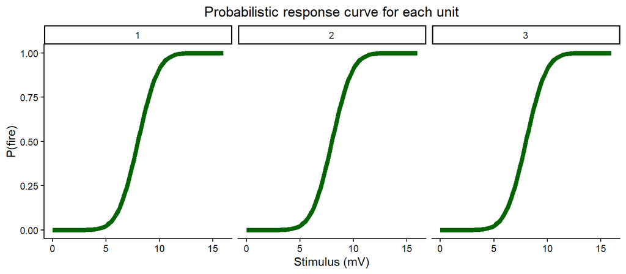

### Poisson-binomial

As shown above, each unit has an accompanying probability of firing at a certain stimulus intensity. This means that the distribution of $I_{i,u}$ (where $I_{i,u}$ indicates whether a specific unit $u$ fires at a specific stimulus $i$), is $I_{i,u} \sim \operatorname{Bernoulli}(P(\mathrm{fire}_{i,u}))$ distributed. Unfortunately, Stan cannot sample latent discrete parameters and therefore sampling $I_{i,u}$ is impossible. However, we can also express this as $I_{i,u} \sim \operatorname{Binomial}(1,P(\mathrm{fire}_{i,u}))$, since these two distributions are equivalent. The total number of activated units at a given stimulus $K_i$ is then Poisson-binomial distributed, as follows:

$$K_i \sim PoissonBinomial(\Theta_{i})$$
The Poisson-binomial distribution describes the sum of $U$ Binomial-distributed variables with potentially different success probabilities. Note that, in our current model, the firing probabilities are still the same across units. However, in later steps, we will allow these probabilities to vary between units, which is why the Poisson-binomial distribution is necessary. $\Theta_i$ denotes the list of firing probabilities, where each unit has its own probability, meaning that the length of this list is equal to the total number of units $U$. Thus, for a specific stimulus $i$, $\Theta_i$ contains the firing probability of each unit in response to that stimulus.

Using the process described so far, we can consider a sequence of varying stimulus intensities $S_i$ and a simulated scenario with fixed values for $U$, $\mu_{\tau}$, and $\sigma_{\tau}$. Given these parameters, $U$ firing probabilities are generated for each stimulus $S_i$, resulting in a set of probabilities $P(\mathrm{fire}_{i,u})$ for each unit $u$. These probabilities determine the latent firing states $I_{i,u}$, where the sum of these latent firing states,

$$K_i = \sum_{u=1}^{U} I_{i,u},$$

is therefore Poisson-binomial distributed. This process allows us to generate data for a simple case. Imagine a case where there are 6 total motor units, and each unit has a random threshold at every stimulus $i$, drawn from a normal distribution, $\tau_{i,u} \sim N(\mu_{\tau},\sigma_{\tau}^2)$. The shared threshold mean $\mu_{\tau}$ is fixed at 10.64, and the standard deviation $\sigma_{\tau}$ is fixed at 2.32. In total, we generate 100 different data points, with the stimulus intensity $S$ ranging from 0 to 16. We then use the process described above to generate the number of active units at each stimulus intensity.

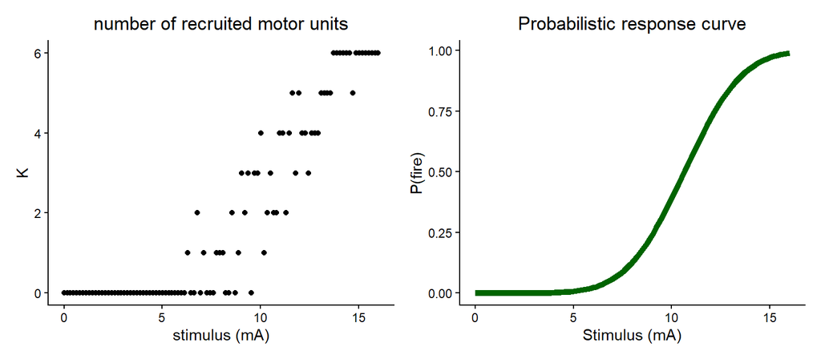

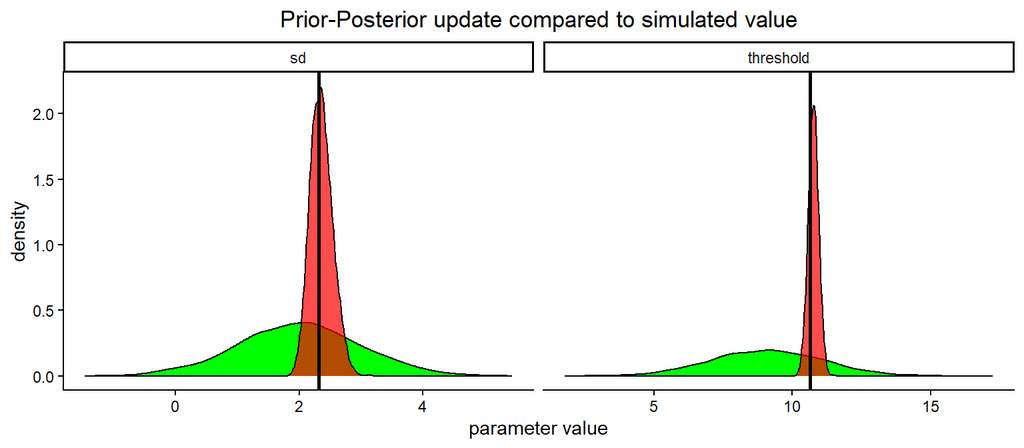

The above plot shows the prior distribution in green, the posterior distribution in red, and the simulated value as a black line. We can see that the posterior has shifted from the prior and places substantial density around the simulated value, suggesting that the parameters are recoverable. The values used here were chosen arbitrarily but other values are retrievable too.

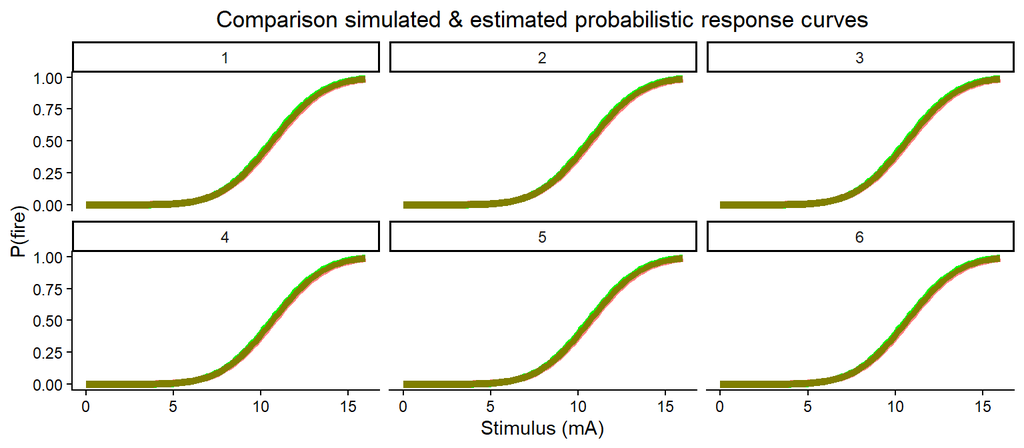

The graph above shows the simulated probabilistic response curves for each unit in green and the corresponding estimated curves in red. All curves are identical because the threshold mean and standard deviation of the instantaneous thresholds are shared across units. Nevertheless, we can see that the probabilistic response curve for each unit can be recovered with very high precision. Therefore, uncertainty around the estimated curves is not shown here.

## Unit-specific threshold means

Obviously, the case discussed above is too simple, as we assumed that the threshold mean was the same for each unit. This meant that, on average, each unit had the same excitability pattern and therefore the same probabilistic firing curve. However, we know from the literature that this is not the case. In addition to instantaneous within-unit variation in threshold, there is also between-unit variation in excitability. Consequently, the overall mean threshold can differ between units, with some units being overall easier to excite than others.

We therefore extended the model by allowing the threshold mean $\mu_{\tau}$ to vary between units, while keeping the within-unit threshold variation $\sigma_{\tau}$ constant across units. This allows us to introduce between-unit variation in excitability while keeping the model relatively simple as we continue to build it up step by step. This results in the instantaneous threshold being distributed as follows:

$$\tau_{i,u} \sim N(\mu_{\tau_u},\sigma_{\tau})$$

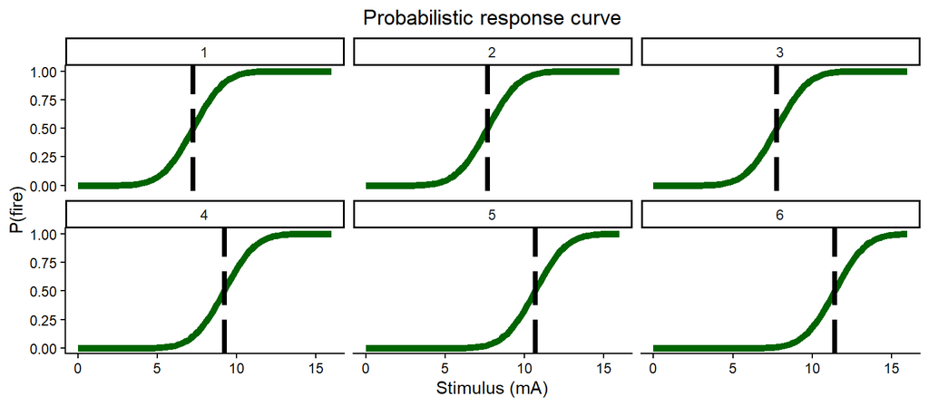

The plot above shows simulated data for this scenario. Each unit has a slightly different threshold mean, with the units ordered from the lowest threshold mean (unit 1) to the highest. This ordering results in a distinct probabilistic firing curve for each unit in response to the stimulus.

We can extend our Stan model to incorporate this between-unit variation and assess whether it can still reliably recover the underlying parameters.

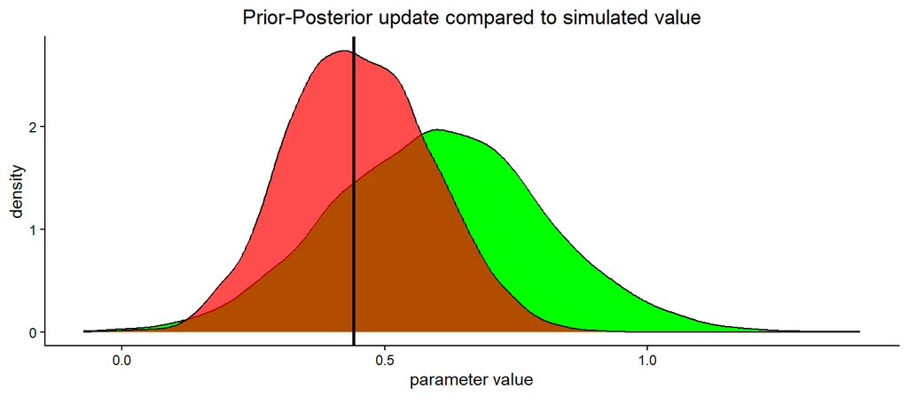

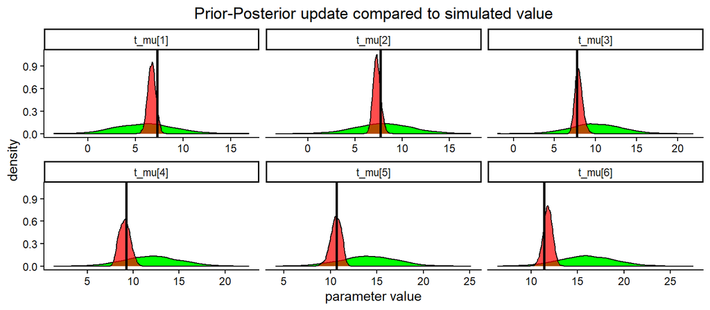

The plot above shows the prior-to-posterior update compared with the simulated values. All parameters remain recoverable, with both the unit-specific threshold means and the shared within-unit variation estimated with reasonable precision. Next, we assess the agreement between the predicted and estimated unit-specific probabilistic firing curves.

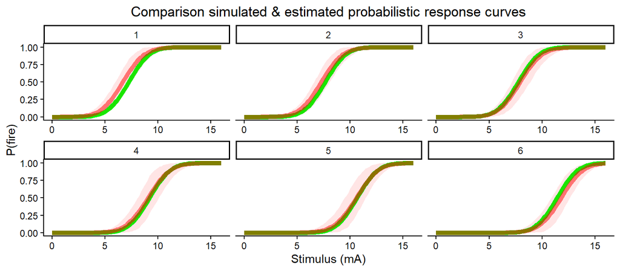

In the plot above, the estimated probabilistic response curves are shown in red, with the corresponding 95% HDIs. Even after incorporating between-unit variation in threshold, the model continues to accurately estimate the individual probabilistic response curves for each unit.

## Optimzing likelihood function

As stated above, the outcome data at the moment is generated by a Poisson-Binomial distribution. However, as Stan does not have a built-in likelihood function for the Poisson-binomial, we have to implement our own likelihood. Up until this point, we have made use of what they call the lexicographic approach. In this approach, for every outcome $K_i$, it iterates over every possible combination that could have generated this outcome. So for example, if you have a total number of $U = 3$ available motor units and $K_i = 2$ units fire, this can be because of the combinations $(u_1, u_2)$ or $(u_1, u_3)$ or $(u_2, u_3)$. It evaluates the likelihood of every combination and estimates the probabilities of the units to fire from that. However, this approach can become computationally expensive as the total number of possible combinations scales exponentially as $2^U$. Below is a plot of how the running time of the lexicographic approach scales with the amount of units to demonstrate this:

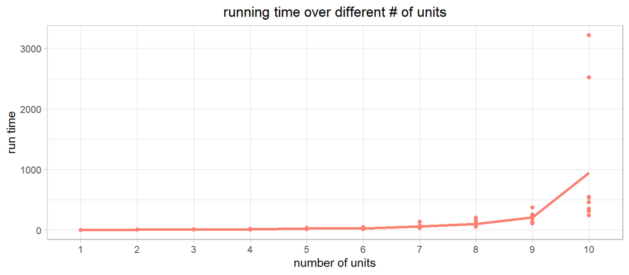

Although it might not seem like much at small scales, the running time increases exponentially as the number of units grows, which is a major bottleneck given that up to 100 motor units can be detected in healthy individuals. Fortunately, this issue has been addressed before by optimizing the likelihood calculation using a dynamic programming approach. Instead of exhaustively enumerating every possible combination of firing units, this method breaks the problem down sequentially by adding one motor unit at a time. Using an $(U + 1) \times (U + 1)$ matrix $\alpha$, it iteratively computes the log-probability of observing $K_i$ firing units out of the first $u$ units by combining the cases where the $u$-th unit either fires on the $i$-th stimulus (with probability $\theta_{u,i}$) or stays silent (with probability $1 - \theta_{u,i}$). This eliminates redundant calculations and reduces the computational complexity from exponential $2^U$ down to quadratic $U^2$, making the scaling substantially less severe. To validate this new implementation, we evaluate the log-likelihoods it produces across a set of $K$ out of $U$ outcomes and compare them against both the lexicographic approach and the analytical solution provided by the R package `poisbinom`. We simulate a vector $\Theta$ of length 10, where every probability is a random draw from a uniform distribution between 0 and 1:

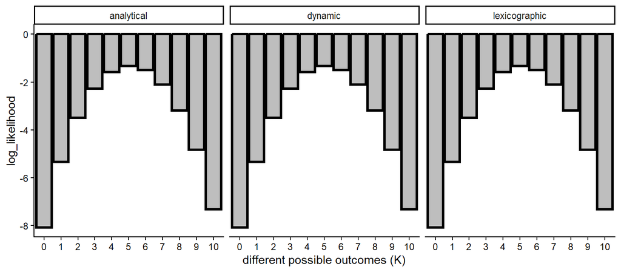

As shown above, all approaches yield identical log-likelihoods for the same probability vector. The final step is to evaluate how the scaling of the dynamic programming approach compares to the lexicographic method. Using the previously simulated datasets, we benchmark the fitting time across an increasing number of units.

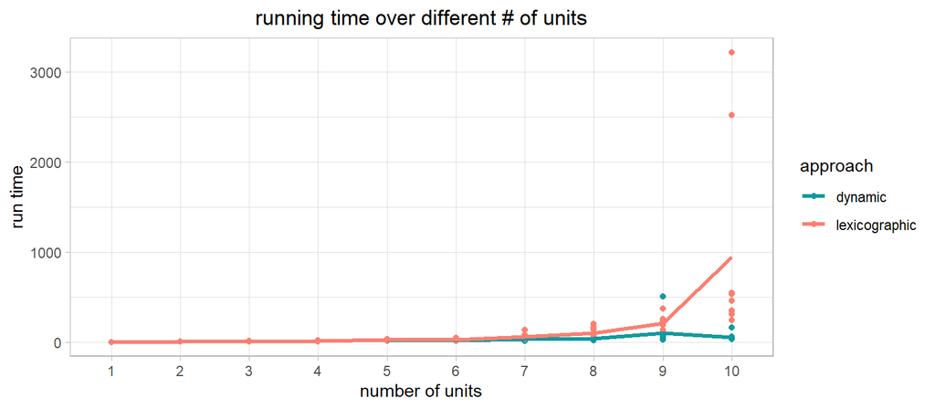

As demonstrated in the plot, the scaling behavior of the dynamic programming approach is substantially more efficient. While running times are comparable at smaller unit sizes, the performance gap widens dramatically as the number of units increases, which is a crucial advantage when scaling to larger systems (e.g. 50 units).

The complete source code for both implementations is available on the [Stan Discourse Forum Discussion](https://discourse.mc-stan.org/t/poisson-binomial-distribution-any-existing-stan-implementation/4220).

## Unit-specific threshold variance

The model described now assumes that all motor units exhibit the same degree of instantaneous threshold variability. In other words, the standard deviation of the instantaneous threshold distribution is assumed to be identical across units. However, this assumption is overly simplistic.

Experimental studies have demonstrated that the variability of motor axonal thresholds is not necessarily identical across individual units. Some motor axons exhibit relatively stable thresholds, whereas others show considerably greater fluctuations in their excitability. This variability is generally quantified using the relative spread (RS), which expresses the standard deviation of the threshold distribution relative to its mean (Hales et al., 2004). To account for this heterogeneity, we can extend the model by allowing the within-unit threshold standard deviation, ($\sigma_{\tau}$), to vary between motor units. This means that each motor unit has its own characteristic degree of instantaneous threshold variability. The instantaneous threshold is therefore distributed as:

$$\tau_{i,u} \sim N(\mu_{\tau_u},\sigma_{\tau_u})$$
Notice how $\sigma_{\tau}$ changed to $\sigma_{\tau_u}$, the unit-specific standard deviation of instantaneous threshold fluctuations for unit $u$. The resulting instantaneous threshold distributions for a simulated example with six motor units ($U =6$) are illustrated below.

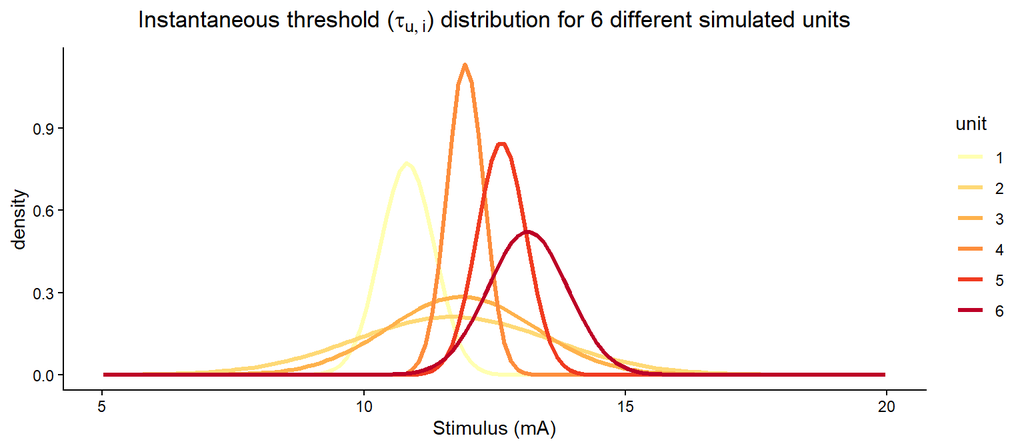

As illustrated in the figure above, the model now captures differences in instantaneous threshold variability between motor units. For example, unit 2 exhibits a relatively broad threshold distribution, indicating greater moment-to-moment fluctuations in excitability. In contrast, unit 4 has a much narrower distribution, reflecting more consistent activation thresholds.

As before, we can translate these threshold distributions into probabilistic firing curves by taking the cumulative distribution function (CDF) of each distribution. These curves show the probability of activating a motor unit and generating an action potential across stimulation intensities. The resulting probabilistic firing curves are shown on the right, along with the data generated from these curves.

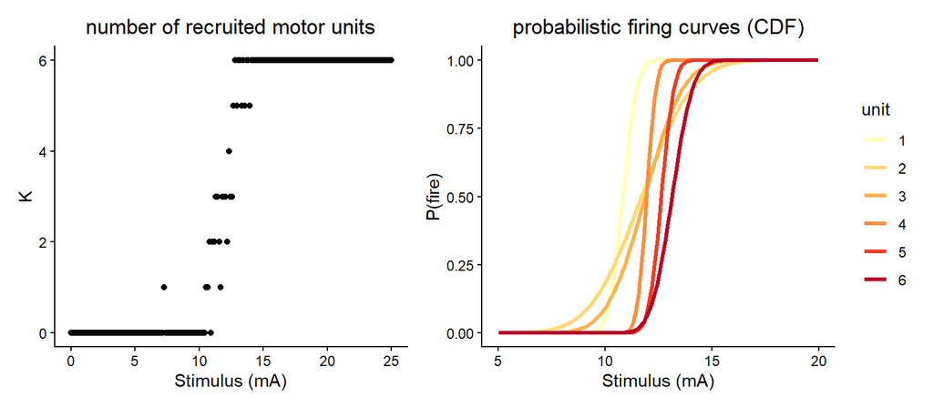

As illustrated above, the probabilistic firing curves now differ between motor units in terms of both their mean activation thresholds and their threshold variability. Consequently, the units exhibit different firing probabilities and slopes (characterized by $\sigma_{\tau_u}$), reflecting differences in both their average excitability and the consistency of their instantaneous thresholds ($\tau_{u,i}$).

We can now fit the updated model to the simulated data to investigate whether it can successfully recover these unit-specific parameters, including both the mean thresholds and their associated standard deviations. Unfortunately, the current parameterization failed to converge and produced many divergences; the pairs plot below shows the resulting posterior geometry for the first 2 threshold variances and means.

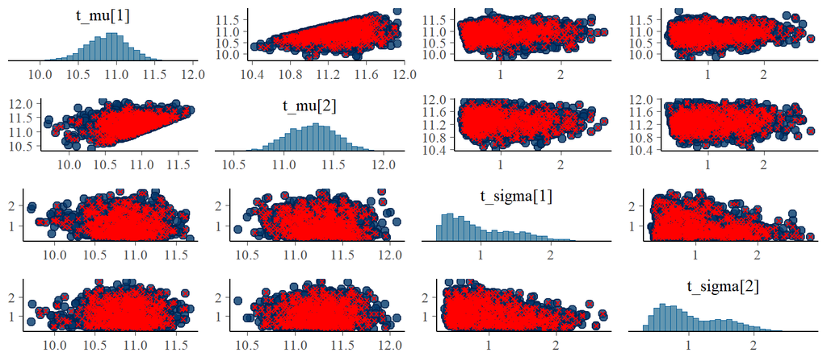

As shown in the pairs plot above, the posterior geometry is difficult to explore, with divergences scattered throughout the parameter space. The sampler appears to struggle particularly with the [ordering constraint](https://mc-stan.org/docs/2_29/reference-manual/ordered-vector.html) on the threshold means, while the variances also prove difficult to estimate, making the root cause hard to isolate. However, leveraging shared information across units via a hierarchical structure may facilitate estimation of the unit-specific parameters.

## Introducing hierarchy

Within the generative framework, it also makes sense to quantify the degree of overlap between motor units. Motor unit excitability may differ systematically between individuals. For example, motor units in patients with ALS may exhibit greater variability in their activation responses than those in healthy controls (Jillapalli & Shefner, 2004). This highlights that we cannot assume the same prior knowledge of unit-specific parameters for everyone, emphasising the need for a measure that captures between-unit properties.

To capture these between-unit characteristics, we want to quantify variation in both the unit-specific threshold means ($\mu_{\tau_u}$) and threshold variances ($\sigma_{\tau_u}$). We can incorporate this into our model by introducing a hierarchical structure for both parameters, allowing information to be shared across units while accounting for between-unit variation. We can incorporate this by modelling each parameter as being generated from a shared normal distribution, with its mean and variance treated as hyperparameters that can vary and that are to be estimated. This gives us the following:

$$\tau_{i,u} \sim N(\mu_{\tau_u},\sigma_{\tau_u})$$
$$\mu_{\tau_u} \sim N(\mu_{\tau},\sigma_{\mu_\tau})$$
$$\sigma_{\tau_u} \sim LN(\mu_{\sigma_\tau},\sigma_{\tau})$$

Note that $\mu_\tau$ retains the same notation but now has a different interpretation. Previously, it represented the shared unit-specific threshold mean across all motor units. In the hierarchical model, it represents the population-level mean of the unit-specific threshold means, while the individual unit-specific values are modelled as draws from this population distribution. It determines the overall location of the probabilistic firing curves in the stimulus space. The variance, $\sigma_{\mu_\tau}$, of this population distribution determines how much the unit-specific threshold means vary around the population mean, $\mu_\tau$. A low variance indicates that the firing curves are clustered closely together around $\mu_\tau$, whereas a high variance indicates greater dispersion across motor units.

The mean of the population distribution of threshold variances, $\mu_{\sigma_\tau}$, determines the overall spread of the individual instantaneous threshold distributions and motor unit firing curves. A higher value indicates greater variability in the firing thresholds within individual motor units, resulting in shallower recruitment curves. Conversely, a lower value produces steeper curves, approaching an all-or-none, step-like firing response. Again, note that $\sigma_{\tau}$ now has a different interpretation than before. Previously, it represented the shared unit-specific standard deviation of the instantaneous threshold distributions across motor units. In the hierarchical model, it represents the between-unit spread of these unit-specific threshold standard deviations. A high value indicates greater heterogeneity in the slopes of the firing curves across motor units, whereas a low value indicates that these slopes are more similar and clustered around the population mean, $\mu_{\sigma_\tau}$. Note that both parameters are defined on the log scale to ensure that the instantaneous threshold standard deviations remain strictly positive.

The following simulation illustrates how each between-unit parameter of the threshold mean ($\mu_{\tau}$, $\sigma_{\mu_\tau}$) influences the shape of the probabilistic firing curves.

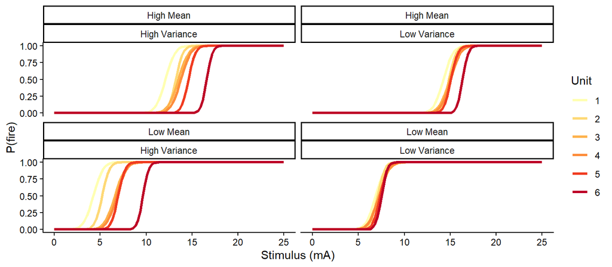

You can see that the population mean of the unit-specific threshold means ($\mu_{\tau}$) determines the location in stimulus space around which the firing curves are centered, whereas their population-level variability ($\sigma_{\mu_\tau}$) determines how widely the curves are distributed around this central location.

Below are the simulations that illustrate how each between-unit parameter of the unit-specific threshold variance ($\mu_{\sigma_\tau}$, $\sigma_{\tau}$) influence the shape of the probabilistic firing curves.

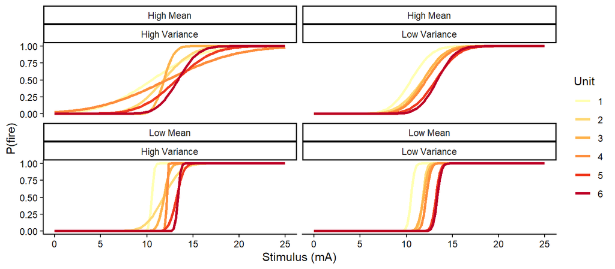

You can see that the population mean of the unit-specific threshold standard deviations ($\mu_{\sigma_\tau}$) determines the overall slope of the firing curves, whereas their population-level variability ($\sigma_{\tau}$) determines the extent to which this steepness varies between units.

We can also assess whether this extension allows us to estimate both unit-specific threshold means and variances. To do so, we fit the hierarchical model to the same data as in the previous section and evaluate its fit.

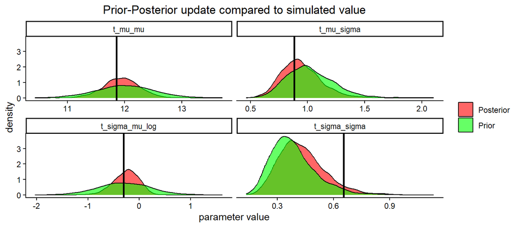

Note that t_mu_mu = $\mu_{\tau}$, t_mu_sigma = $\sigma_{\mu_{\tau}}$, t_sigma_mu_log = $\mu_{\sigma_{\tau}}$, and t_sigma_sigma = $\sigma_{\sigma_{\tau}}$.

We can see that the posterior distributions of the population means ($\mu_{\tau}$, $\mu_{\sigma_{\tau}}$) attributes more density towards the true values, indicating that these parameters are reasonably well estimated. The variance parameters, particularly the between-unit variability in the unit-specific threshold standard deviations, are more difficult to estimate (as we will also see later when increasing the number of units). Their posterior distributions remain largely centred around the prior, suggesting that the data provide limited information about the degree of between-unit variability. This is expected given the relatively small number of units and the low simulated variability. Since our primary interest is estimating the number of motor units, this limitation is not a major concern at this stage. We can now assess whether the model successfully recovers the probabilistic firing curves, providing insight into its ability to estimate unit-specific parameters.

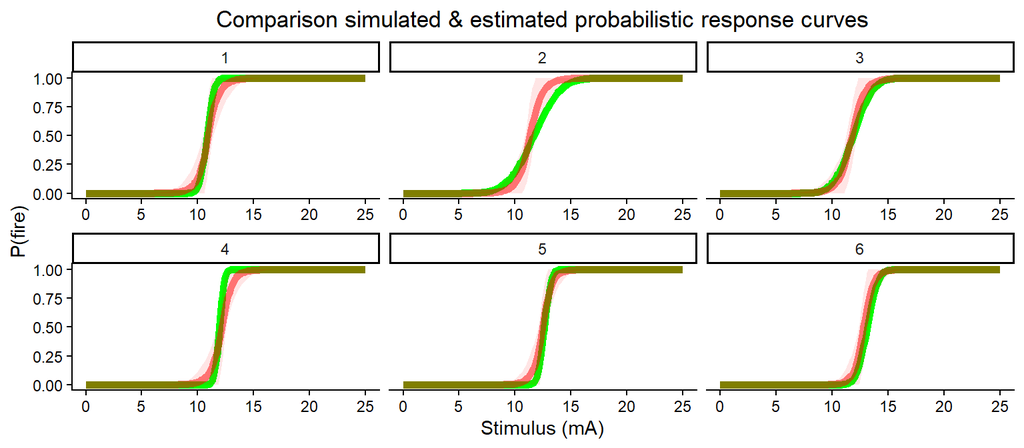

As shown, the model can recover individual firing curves with reasonable precision. Although the estimated slopes and thresholds occasionally deviate slightly from their simulated values, the estimated curves generally remain within the range of the simulated curves.

One caveat is that probabilities had to be constrained to the interval $[1e^{-12};1-1e^{-12} ]$ to facilitate sampling. Although this is not entirely elegant from a mechanistic perspective, the substantial improvement in sampler performance justifies this pragmatic choice. An important next step is to investigate whether these recovery results hold as the number of available motor units increases.

## Increasing the number of available motor units

So far, we have fixed the total number of available units ($U$) at a relatively low value of around 6 motor units. This is low even for some patient populations, where the number of available motor units can be considerably higher. In healthy controls, this number can reach and even exceed 100, making the scenarios considered so far relatively simplistic. We will therefore investigate model fits with 10, 20, 30, 35, and 50 available motor units to assess whether the model continues to provide reliable estimates as the number of units increases. Below, we examine parameter recovery when fitting the same model to datasets containing 10, 20, 30, and 35 motor units. Each point represents a single simulation generated from the model and subsequently fitted using the same model. In total, 100 simulations were performed, with 25 simulations for each value of $U$. All fits ended in 0 divergent transitions.

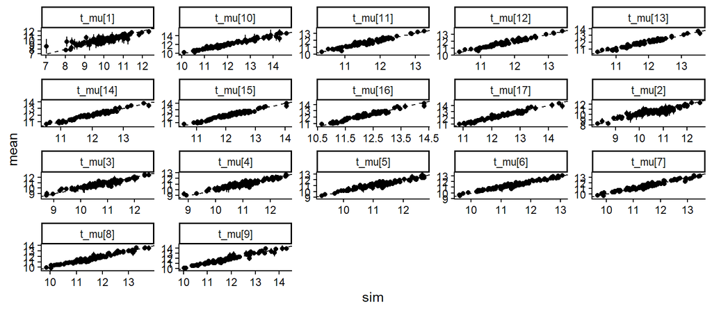

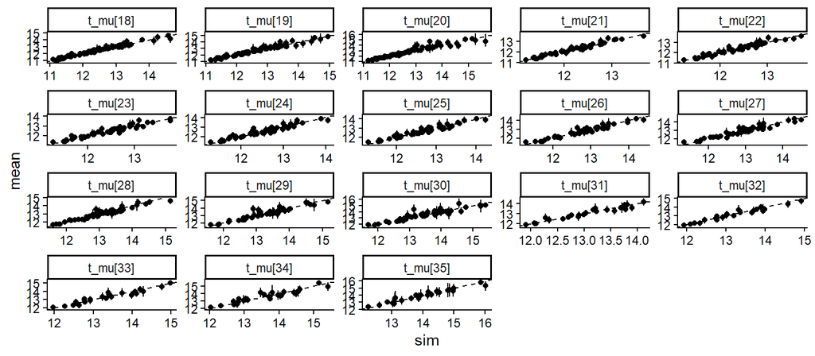

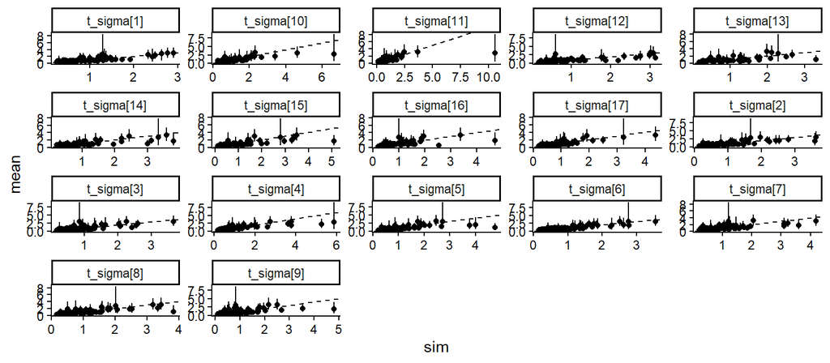

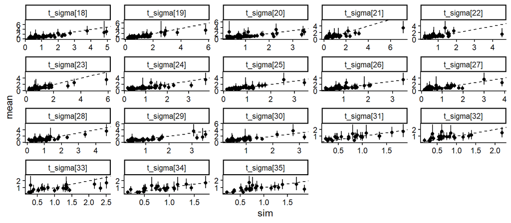

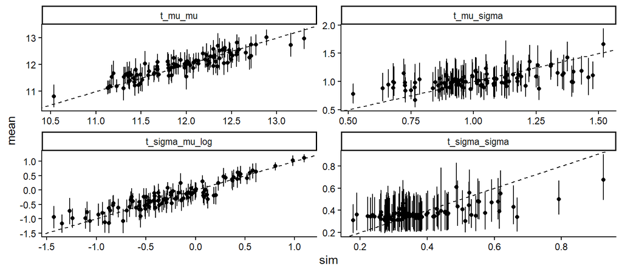

We can see that most parameters are recovered reasonably well, with $\mu_{\tau_u}$ (t_mu[u]) following the identity line particularly closely. The unit-specific standard deviations, $\sigma_{\tau_u}$ (t_sigma[u]), are also generally recoverable, although estimates tend to shrink towards the prior when the true values are relatively high. This behaviour is expected given the influence of the prior and is not a concern. Regarding the group-level parameters, the population means ($\mu_{\tau}$ and $\mu_{\sigma_\tau}$) are recovered reasonably well. However, the population-level standard deviations ($\sigma_{\mu_\tau}$ and $\sigma_{\tau}$), which capture between-unit variability in the unit-specific means and standard deviations, show a tendency to shrink towards their prior means. As discussed earlier, this is not a major concern at this stage, given the relatively limited information available to estimate between-unit variability.

We can extend this analysis to the case of 50 available motor units. However, displaying all parameter recovery plots becomes impractical in this case. Instead, we focus on comparing the simulated and estimated probabilistic firing curves to assess whether the model can still recover unit-specific firing behaviour.

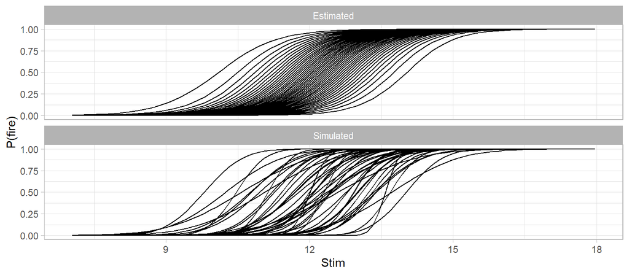

For larger numbers of motor units, we observe a potential trade-off between the steepness of the probabilistic firing curves and their spread across the stimulus space. This suggests a possible trade-off between $\sigma_{\mu_\tau}$ and $\mu_{\sigma_\tau}$. At this stage, however, it is unclear whether this relationship affects the estimation of the total number of motor units, and we therefore do not consider it a concern for now. Nevertheless, it is an aspect worth revisiting in future analyses.

## References

Baumann, F., Henderson, R. D., Gareth Ridall, P., Pettitt, A. N., & McCombe, P. A. (2012). Quantitative studies of lower motor neuron degeneration in amyotrophic lateral sclerosis: Evidence for exponential decay of motor unit numbers and greatest rate of loss at the site of onset. *Clinical Neurophysiology*, *123*(10), 2092–2098. https://doi.org/https://doi.org/10.1016/j.clinph.2012.03.007

Bostock, H. (2016). Estimating motor units numbers from a CMAP scan. *Muscle & Nerve*, *53*(6), 889–896. https://doi.org/https://doi.org/10.1002/mus.24945

Brown, W. F., & Milner-Brown, H. S. (1976). Some electrical properties of motor units and their effects on the methods of estimating motor unit numbers. *Journal of Neurology, Neurosurgery & Psychiatry*, *39*(3), 249–257. https://doi.org/10.1136/jnnp.39.3.249

Hales, J. P., Lin, C. S.-Y., & Bostock, H. (2004). Variations in excitability of single human motor axons, related to stochastic properties of nodal sodium channels. *The Journal of Physiology*, *559*(3), 953–964. https://doi.org/https://doi.org/10.1113/jphysiol.2004.068726

Jillapalli, D., & Shefner, J. M. (2004). Single motor unit variability with threshold stimulation in patients with amyotrophic lateral sclerosis and normal subjects. *Muscle & Nerve*, *30*(5), 578–584. https://doi.org/https://doi.org/10.1002/mus.20147

Ridall, P. G., Pettitt, A. N., Henderson, R. D., & McCombe, P. A. (2006). Motor unit number estimation—a bayesian approach. *Biometrics*, *62*(4), 1235–1250. https://doi.org/10.1111/j.1541-0420.2006.00577.x

Slawnych, M., Laszlo, C., & Hershler, C. (1996). Motor unit estimates obtained using the new “MUESA” method. *Muscle & Nerve*, *19*(5), 626–636. https://doi.org/https://doi.org/10.1002/(SICI)1097-4598(199605)19:5<626::AID-MUS11>3.0.CO;2-L